[figure not shown]

# What Makes An Effective Leader?

Advanced Methods for Statistical Inference Assignment #2

Yun (Jessica) Yan

2019-11-21

# Intro

Why are some people seen as effective leaders and others are not? Are there any behaviors or characteristics that can help us quantify what an effective leader looks like? We use the data from a large survey of employees and their direct manager (i.e., each leader provided self-ratings and their direct subordinates provided rating about the leader – this is reflected by the `Rater` variable). This data contains individual items and the scale score for those items. Our main goal is to use individual items, scale subscores, and/or scale scores to explain the *effect* variable.

# Loading

```r
library(tidyverse)
library(summarytools)
st_css()
```

```r
load("C:/Users/Administrator/Downloads/teamPerc.RData")
teamPerc <- sjlabelled::remove_all_labels(teamPerc)
```

# Bronze

## i. Hypotheses

After examining the variables within the given data, I would like to examine the linear relationship between the *effect* variable and the four scales. The regression model is:
$$effect = \beta_{0} + \beta_{1}forceful + \beta_{2}enabling + \beta_{3}strategic + \beta_{4}operational$$
.

My hypotheses are as follow:

Null hypothesis 1: $β_{1} = 0$. There is no relationship between the *effect* variable and the *forceful* variable.

Null hypothesis 2: $β_{2} = 0$. There is no relationship between the *effect* variable and the *enabling* variable.

Null hypothesis 3: $β_{3} = 0$. There is no relationship between the *effect* variable and the *strategic* variable.

Null hypothesis 4: $β_{4} = 0$. There is no relationship between the *effect* variable and the *operational* variable.

## ii. Data Selection

After observation, we found that in the *Rater* column, the number of **3** is quite more than the number of **1**, which suggests that **3** should represent the subordinate ratings while **1** represents the leader ratings. Since we are most interested in subordinate ratings, we want to get only the subordinate ratings in our data.

```r
teamPerc1 <- teamPerc %>%
  filter(Rater == 3) %>%
  select(effect,forceful,enabling,strategic,operational) %>%
  filter_at(vars(1:5),all_vars(!is.na(.)))

print(dfSummary(teamPerc1,graph.magnif = 0.7),
      max.tbl.height = 350, method = "render",headings=FALSE)
```

| **No** | **Variable** | **Stats / Values** | **Freqs (% of Valid)** | **Graph** | **Valid** | **Missing** |
| --- | --- | --- | --- | --- | --- | --- |
| 1 | effect [numeric] | Mean (sd) : 8.2 (1.3) min < med < max: 0 < 8.5 < 10 IQR (CV) : 1.5 (0.2) | 202 distinct values |  | 20419 (100%) | 0 (0%) |
| 2 | forceful [numeric] | Mean (sd) : 0 (0.6) min < med < max: -4.8 < 0 < 4 IQR (CV) : 0.5 (40.7) | 18597 distinct values |  | 20419 (100%) | 0 (0%) |
| 3 | enabling [numeric] | Mean (sd) : 0 (0.5) min < med < max: -3.8 < 0.1 < 2.8 IQR (CV) : 0.3 (-12.7) | 18597 distinct values |  | 20419 (100%) | 0 (0%) |
| 4 | strategic [numeric] | Mean (sd) : 0 (0.4) min < med < max: -3.7 < 0.1 < 2.8 IQR (CV) : 0.3 (-30.3) | 18597 distinct values |  | 20419 (100%) | 0 (0%) |
| 5 | operational [numeric] | Mean (sd) : 0 (0.2) min < med < max: -1.6 < 0 < 1.2 IQR (CV) : 0.1 (-76.8) | 18597 distinct values |  | 20419 (100%) | 0 (0%) |

Generated by summarytools 0.9.4 ([R](https://www.r-project.org/) version 3.6.1)  
2019-11-21

## ii. Power Analysis

We conduct an *a prior* power analysis to determine the sample size needed for the effect size. Since we want to be conservative, we firstly get the conventional small effect sizes, which is .02 (Detecting smaller effects require larger sample sizes.).

```r
pwr::cohen.ES("f2", "small")
```

```
##
##      Conventional effect size from Cohen (1982)
##
##            test = f2
##            size = small
##     effect.size = 0.02
```

```r
pwr::pwr.f2.test(u = 4,
            f2 = .02,
            sig.level = .05,
            power = .8)
```

```
##
##      Multiple regression power calculation
##
##               u = 4
##               v = 596.5271
##              f2 = 0.02
##       sig.level = 0.05
##           power = 0.8
```

Based on the formula $n = v + u + 1$. Therefore we need $597 + 4 + 1 = 602$ records.

```r
pwr::pwr.f2.test(u = 4,
            f2 = (0.1)/(1-0.1),
            sig.level = .05,
            power = .8)
```

```
##
##      Multiple regression power calculation
##
##               u = 4
##               v = 107.2643
##              f2 = 0.1111111
##       sig.level = 0.05
##           power = 0.8
```

Also, based on our experience, we consider that the independent variables we chose can explain 10% of the variance of our dependent variable. Using $f^2 = \frac{R^2_{adjusted}}{1 - R^2_{adjusted}}$ as our effect size, we know that we need 113 records.

We can see that there are **20419** observations in our data, which is far more than **602** and **113**. Therefore, it is safe for us to keep moving forward.

## iii. Hypothesis Testing

For each independent variable, we can see that the linear regression model has conducted a t-test on its coefficient, which can be used to test our hypotheses.

```r
lm <- lm(effect ~ forceful + enabling + strategic + operational, data = teamPerc1)
summary(lm)
```

```
##
## Call:
## lm(formula = effect ~ forceful + enabling + strategic + operational,
##     data = teamPerc1)
##
## Residuals:
##     Min      1Q  Median      3Q     Max
## -9.8679 -0.5294  0.1811  0.7209  6.3452
##
## Coefficients:
##              Estimate Std. Error  t value Pr(>|t|)
## (Intercept)  8.250990   0.007834 1053.287  < 2e-16 ***
## forceful    -0.158101   0.058490   -2.703  0.00688 **
## enabling     0.850339   0.063952   13.297  < 2e-16 ***
## strategic    0.746671   0.053453   13.969  < 2e-16 ***
## operational  1.195517   0.092231   12.962  < 2e-16 ***
## ---
## Signif. codes:  0 '***' 0.001 '**' 0.01 '*' 0.05 '.' 0.1 ' ' 1
##
## Residual standard error: 1.114 on 20414 degrees of freedom
## Multiple R-squared:  0.248,  Adjusted R-squared:  0.2478
## F-statistic:  1683 on 4 and 20414 DF,  p-value: < 2.2e-16
```

First of all, we discuss the **R-squared**. The Adjusted R-squared value is 0.2478, which means that 24.78% of the variability within effect can be accounted for the four scales.

Then, we discuss **the F-test**. We used the F-test to compare the entire set of predictors in our model, to a model with just an intercept. The p-value being very small means that our model is very significant overall, in other words, there is a significant linear relationship between the dependent variable and the multiple independent variables.

## iv. Visualizations

```r
cols <- c("forceful"="orange","enabling"="red","strategic"="blue","operational"="yellow")
p1 <- teamPerc1 %>%
  ggplot()+
  geom_smooth(aes(x=forceful,y=effect,color="forceful"),method="lm",se=FALSE)+
  geom_smooth(aes(x=enabling,y=effect,color="enabling"),method="lm",se=FALSE,alpha=0.5)+
  geom_smooth(aes(x=strategic,y=effect,color="strategic"),method="lm",se=FALSE,alpha=0.5)+
  geom_smooth(aes(x=operational,y=effect，color="operational"),method="lm",se=FALSE)+
  ggthemes::theme_stata()+
  theme(axis.title.x = element_blank(),)+
  scale_colour_manual(name="var_name",values=cols)
plotly::ggplotly(p1)
```

[interactive chart not shown]

Interactive plot is employed for better user experience. You can hover onto the three lines that are really close to each other to see the specific value.

# Silver

We use **bootstrap resampling** method to examine how accurate our estimates might be.

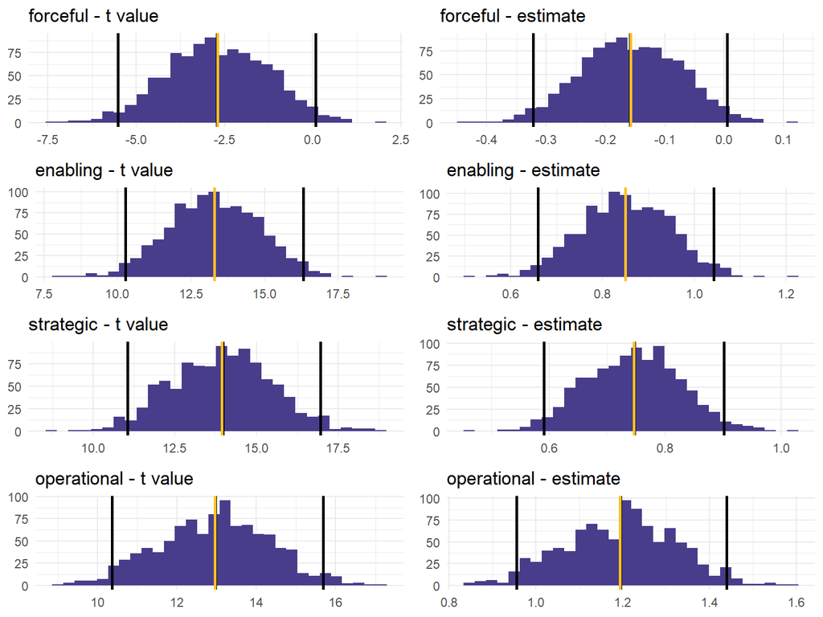

```r
set.seed(1234)
bootstrapping <- function(df) {
  df <- df
  sampledRows <- sample(1:nrow(df), nrow(df), replace = TRUE)
  df <- df[sampledRows, ]
  bsMod <- lm(effect ~ forceful + enabling + strategic + operational, data = df)
  results <- broom::tidy(bsMod)
  return(results)
}

bsRep <- replicate(1000, bootstrapping(teamPerc1), simplify = FALSE)

bsCombined <- do.call("rbind", bsRep)

for(j in c('forceful','enabling','strategic','operational')){
  assign(paste0(substr(j,1,1),'1'),
         ggplot(bsCombined[bsCombined$term == j, ], aes(statistic)) +
           geom_histogram(fill = "darkslateblue") +
           geom_vline(xintercept = quantile(bsCombined$statistic[bsCombined$term == j], .975),size=1) +
           geom_vline(xintercept = quantile(bsCombined$statistic[bsCombined$term == j], .025),size=1) +
           geom_vline(xintercept = summary(lm)$coefficients[j,"t value"],size=1) +
           geom_vline(xintercept = mean(bsCombined$statistic[bsCombined$term == j]),color="goldenrod1",size=1) +
           theme_minimal()+
           labs(title = paste0(j,' - t value'))+
           theme(axis.title.x = element_blank(),
                 axis.title.y = element_blank(),))
  assign(paste0(substr(j,1,1),'2'),
         ggplot(bsCombined[bsCombined$term == j, ], aes(estimate)) +
           geom_histogram(fill = "darkslateblue") +
           geom_vline(xintercept = quantile(bsCombined$estimate[bsCombined$term == j], .975),size=1) +
           geom_vline(xintercept = quantile(bsCombined$estimate[bsCombined$term == j], .025),size=1) +
           geom_vline(xintercept = summary(lm)$coefficients[j,"Estimate"],size=1) +
           geom_vline(xintercept = mean(bsCombined$estimate[bsCombined$term == j]),color="goldenrod1",size=1) +
           theme_minimal()+
           labs(title = paste0(j,' - estimate'))+
           theme(axis.title.x = element_blank(),
                 axis.title.y = element_blank(),))
}

gridExtra::grid.arrange(f1,f2,e1,e2,s1,s2,o1,o2,nrow=4,ncol=2)
```

As for the forceful variable, 95% of the intervals contain the true t-value between -5.5 and 0 and 95% of the intervals of its coefficient ranges from -0.3 to 0. There is some variance for the forceful variable and we need to keep in mind that there are chances that forceful is not a significant predictor for effect.

As for the enabling, strategic and operational variables, 95% of the intervals of their t-values all far more than 1.96 while 95% of the intervals of their coefficient estimation are all positive. We should have confidence that they would be significant predictors for the effect variable.

# Gold

One of the assumptions about our regression model is that we don’t have heteroscedasticity, which means the residual standard error should be fixed. However, we need to conduct some tests to confirm it. Firstly, the residual plot shows a certain pattern instead of randomly distributed, and the red line in the graph is not fairly flat. Therefore, it is highly likely that our model has heteroscedasticity.

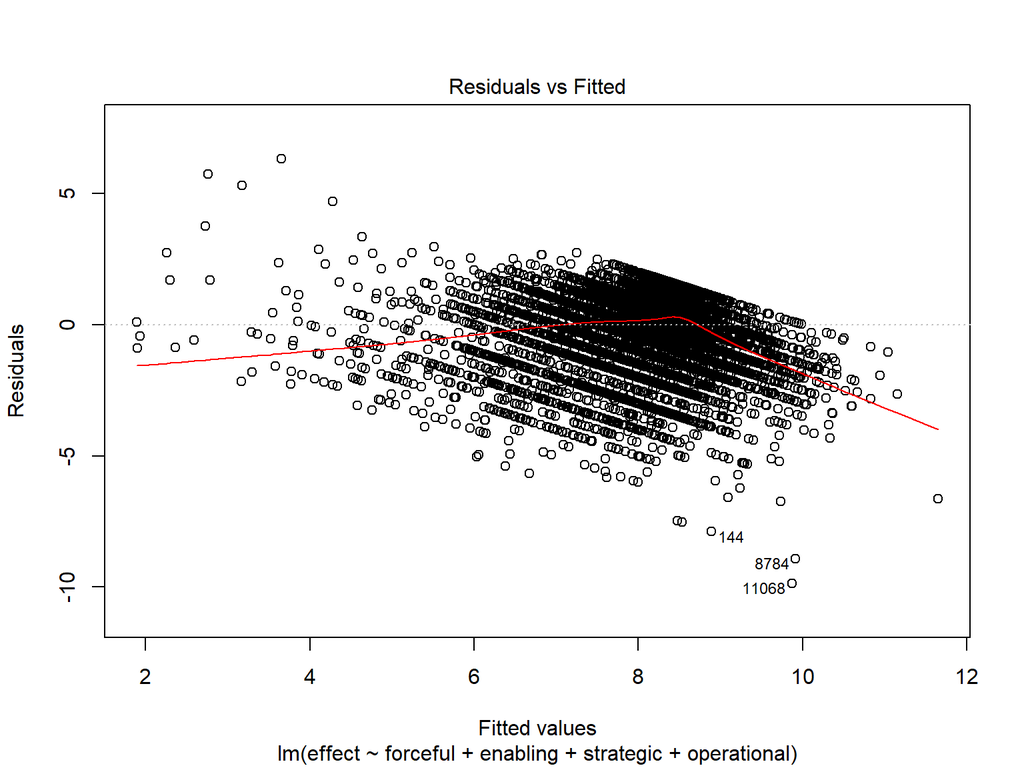

```r
plot(lm,which=1)
```

Then, we conduct the bp-test to check it algorithimcally. According to the result, our p-value is very small, and thus we can reject the null hypothesis that the variance of the residuals is constant and heteroskedacity is present.

```r
lmtest::bptest(lm)
```

```
##
##  studentized Breusch-Pagan test
##
## data:  lm
## BP = 123.9, df = 4, p-value < 2.2e-16
```

Next, we use the `vcocHC` function to correct our variance-covariance matrix.

```r
lmtest::coeftest(lm, vcov = sandwich::vcovHC(lm))
```

```
##
## t test of coefficients:
##
##               Estimate Std. Error   t value Pr(>|t|)
## (Intercept)  8.2509902  0.0078182 1055.3577  < 2e-16 ***
## forceful    -0.1581015  0.0851025   -1.8578  0.06322 .
## enabling     0.8503390  0.0988199    8.6049  < 2e-16 ***
## strategic    0.7466709  0.0812148    9.1938  < 2e-16 ***
## operational  1.1955173  0.1290890    9.2612  < 2e-16 ***
## ---
## Signif. codes:  0 '***' 0.001 '**' 0.01 '*' 0.05 '.' 0.1 ' ' 1
```

After the correction, We see that the standard errors differ from the standard errors in our original linear regression model. The **forceful** variable is not statistically significant under the 0.05 significant level anymore. It also aligns with our finding in the resampling section.

# Findings

- If someone wants to be an effective leader, being enabling, strategic and oprational would be helpful to his / her subordinate ratings while being forceful might be harmful. He / She might want to avoid over-charging and being pushy.
- The operational characteristic is most useful for improving the effectiveness of the leader since this variable has the highest coefficient in our linear regression model. In other words, the most urgent things for a leader who wants to be more effective is to be more action-oriented and improve the working efficiency.
- Due to time limitation, my current analysis only focus on the scale level. We can dive deeper into the subscales and individual items next time. Also, comparison analysis can be conducted on the results of the leader and subordinate ratings.

back to top